# Data624_HW5

Alexis Mekueko

10/10/2021

[Github Link](https://github.com/asmozo24/Data624_HW5) [Web Link](https://rpubs.com/amekueko/814927)

## Exercise 1. Consider the the number of pigs slaughtered in Victoria, available in the aus_livestock dataset.

a-Use the ETS() function to estimate the equivalent model for simple exponential smoothing. Find the optimal values of α and ℓ_0 , and generate forecasts for the next four months.

```r
#head(aus_livestock)
View(aus_livestock)
#view(aus_livestock$Animal [18000:18100]) # %>% filter(Animal =="Lambs"))
min(aus_livestock$Month)
```

```
## <yearmonth[1]>
## [1] "1972 Jul"
```

```r
aus3 <- aus_livestock %>%
                      filter(Animal == "Pigs", State == "Victoria")

fit <- aus3$Count %>%
       ses(h=4)
fit$model
```

```
## Simple exponential smoothing
##
## Call:
##  ses(y = ., h = 4)
##
##   Smoothing parameters:
##     alpha = 0.322
##
##   Initial states:
##     l = 100646.6098
##
##   sigma:  9353.115
##
##      AIC     AICc      BIC
## 13737.10 13737.14 13750.07
```

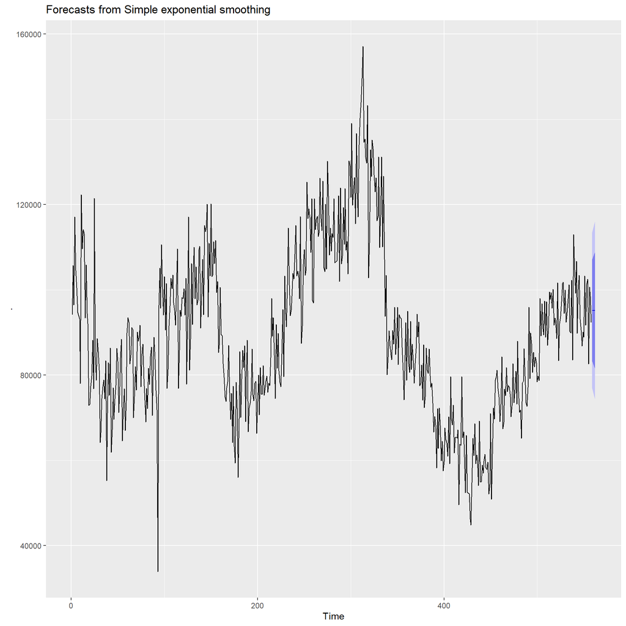

```r
autoplot(fit)
```

Based on the Simple Exponential Smoothing (ses) call, α = 0.322, l = 100646.6098

b-Compute a 95% prediction interval for the first forecast using ^y±1.96s where s is the standard deviation of the residuals. Compare your interval with the interval produced by R.

```r
predi_low <- fit$mean - 1.96*(sd(fit$residuals)) #76871.23
predi_high <- fit$mean + 1.96*(sd(fit$residuals)) #113502.3
predi_high; predi_low
```

```
## Time Series:
## Start = 559
## End = 562
## Frequency = 1
## [1] 113502.3 113502.3 113502.3 113502.3
```

```
## Time Series:
## Start = 559
## End = 562
## Frequency = 1
## [1] 76871.23 76871.23 76871.23 76871.23
```

```r
fit #76855.01....113518.5
```

```
##     Point Forecast    Lo 80    Hi 80    Lo 95    Hi 95
## 559       95186.77 83200.27 107173.3 76855.01 113518.5
## 560       95186.77 82594.29 107779.3 75928.23 114445.3
## 561       95186.77 82016.16 108357.4 75044.05 115329.5
## 562       95186.77 81462.36 108911.2 74197.09 116176.5
```

## Exercise 5. Data set global_economy contains the annual Exports from many countries. Select one country to analyse.

a- Plot the Exports series and discuss the main features of the data.

```r
??global_economy
```

```
## starting httpd help server ... done
```

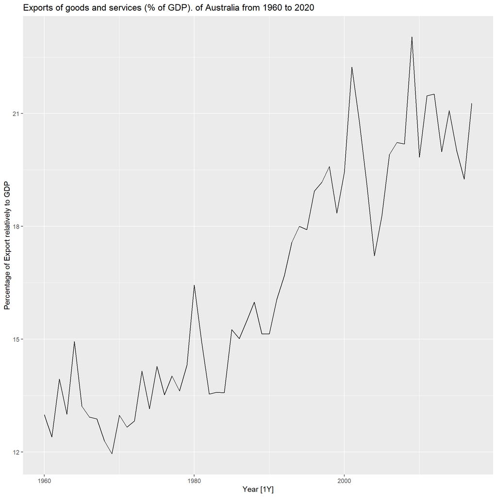

```r
aus4 <- global_economy %>%
               filter(Country == "Australia")#%>%
               #model(RW(Population ~ drift())) %>%
               #forecast(h = "5 years") %>%
#view(aus4)
                                                                                     #autoplot(global_economy) + labs(y = "Number of People", title = "Population of Australia from 1960 to 2025")

global_economy %>%
                filter(Country == "Australia") %>%
                                               autoplot(Exports) +
                                               labs(y = "Percentage of Export relatively to GDP", title = "Exports of goods and services (% of GDP). of Australia from 1960 to 2020")
```

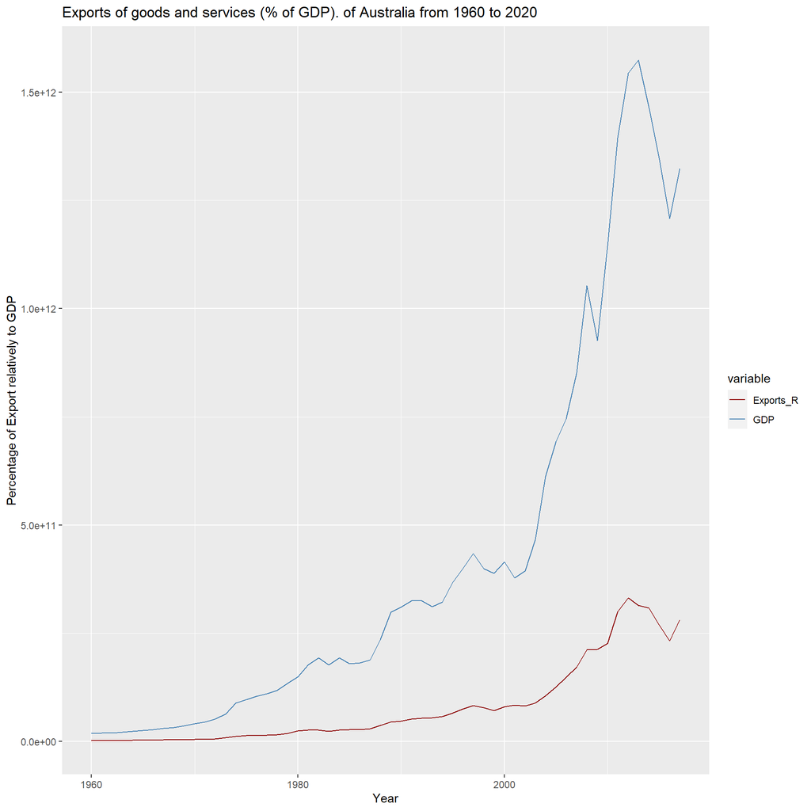

```r
aus4a <- global_economy %>%
                filter(Country == "Australia") %>%
                #mutate(GDP = round(GDP,5))%>%
                mutate(Exports_R = round(((GDP*Exports)/100), 5))%>%
                dplyr::select(Year, GDP, Exports_R)
#view(aus4a)
#plot.ts(aus4a, plot.type = "single")
aus4a1 <- aus4a %>%
          gather(key = "variable", value = "value", -Year)

ggplot(aus4a1, aes(x = Year, y = value)) +
  geom_line(aes(color = variable)) +
  scale_color_manual(values = c("darkred", "steelblue"))+labs(y = "Percentage of Export relatively to GDP", title = "Exports of goods and services (% of GDP). of Australia from 1960 to 2020")
```

```r
#ts.plot(aus4a,gpars= list(col=rainbow(3))) #, main = "Exports of goods and services (% of GDP). of Australia from 1960 to 2020", xlab = "Years", las=3, ylab = "Percentage of Export relatively to GDP")
#legend("right", names(aus4a[2:3]), col=2:3, lty=1)
#title("Exports of goods and services (% of GDP). of Australia from 1960 to 2020")
#max(aus4$Year)
```

We chose the Australia data and we observed that in the long run the GDP increased proportionally to the exports. So, overall Australia did good from 1960 to 2017. In fact, around year of 2000-2012, Australia had a sudden peak in their GDP which is explained by the rise of their exports. There were few recessions but didn’t last long. Australia economy shows a fast recovery.

b- Use an ETS(A,N,N) model to forecast the series, and plot the forecasts.

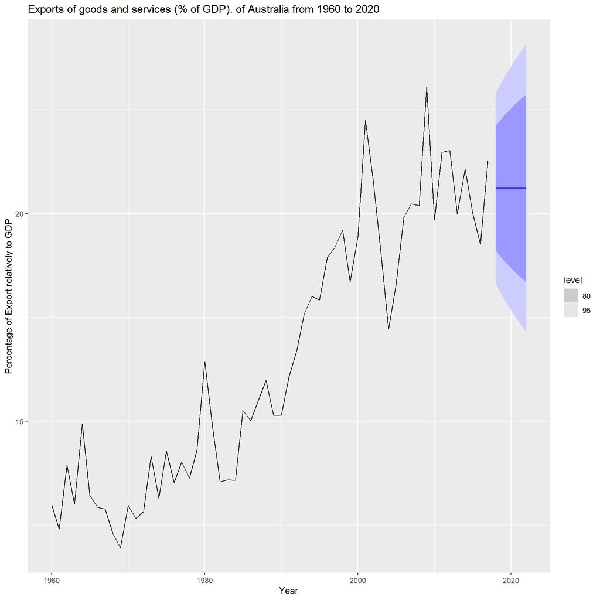

```r
fit <- aus4 %>%
  model(ETS(Exports ~ error("A") + trend("N") + season("N")))
fc <- fit %>%
  forecast(h = 5)
fc %>%
  autoplot(aus4)+labs(y = "Percentage of Export relatively to GDP", title = "Exports of goods and services (% of GDP). of Australia from 1960 to 2020")
```

c-Compute the RMSE values for the training data.

```r
fit %>%
  accuracy()
```

```
## # A tibble: 1 x 11
##   Country  .model         .type    ME  RMSE   MAE   MPE  MAPE  MASE RMSSE   ACF1
##   <fct>    <chr>          <chr> <dbl> <dbl> <dbl> <dbl> <dbl> <dbl> <dbl>  <dbl>
## 1 Austral~ "ETS(Exports ~ Trai~ 0.232  1.15 0.914  1.09  5.41 0.928 0.928 0.0125
```

RMSE = 1.146794

d-Compare the results to those from an ETS(A,A,N) model. (Remember that the trended model is using one more parameter than the simpler model.) Discuss the merits of the two forecasting methods for this data set.

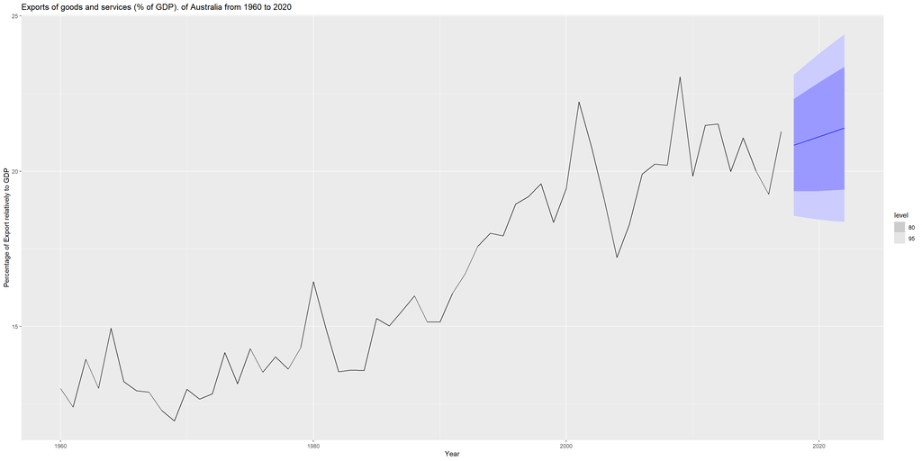

```r
fit1 <- aus4 %>%
  model(ETS(Exports ~ error("A") + trend("A") + season("N")))
fc1 <- fit1 %>%
  forecast(h = 5)
fc1 %>%
  autoplot(aus4)+labs(y = "Percentage of Export relatively to GDP", title = "Exports of goods and services (% of GDP). of Australia from 1960 to 2020")
```

```r
fit1 %>%
  accuracy()
```

```
## # A tibble: 1 x 11
##   Country  .model      .type       ME  RMSE   MAE    MPE  MAPE  MASE RMSSE  ACF1
##   <fct>    <chr>       <chr>    <dbl> <dbl> <dbl>  <dbl> <dbl> <dbl> <dbl> <dbl>
## 1 Austral~ "ETS(Expor~ Trai~ -7.46e-7  1.12 0.893 -0.387  5.39 0.907 0.904 0.109
```

Well, the ETS(A,A,N)model shows an upward trend line compared to the ETS(A,N,N)model. We think the ETS(A,A,N) model is the best.

f - Calculate a 95% prediction interval for the first forecast for each model, using the RMSE values and assuming normal errors. Compare your intervals with those produced using R.

```r
predi_low_ANN <- fc$.mean - 1.96*(1.146794) #18.35944
predi_high_ANN <- fc$.mean + 1.96*(1.146794) #22.85488
predi_low_AAN <- fc1$.mean - 1.96*(1.116727) #19.19850
predi_high_AAN <- fc1$.mean + 1.96*(1.116727) #23.57607

#fc$Exports #N(21, 1.4)
#fc1$Exports #N(21, 1.3)
```

Predicted interval ETS(ANN)model = [18.35944,22.85488] Interval produced by R = N(21, 1.4)

Predicted interval ETS(AAN)model = [19.19850,23.57607] Interval produced by R = N(21, 1.3)

## Exercise 6: Forecast the Chinese GDP from the global_economy data set using an ETS model. Experiment with the various options in the ETS() function to see how much the forecasts change with damped trend, or with a Box-Cox transformation. Try to develop an intuition of what each is doing to the forecasts.

[Hint: use a relatively large value of h when forecasting, so you can clearly see the differences between the various options when plotting the forecasts.]

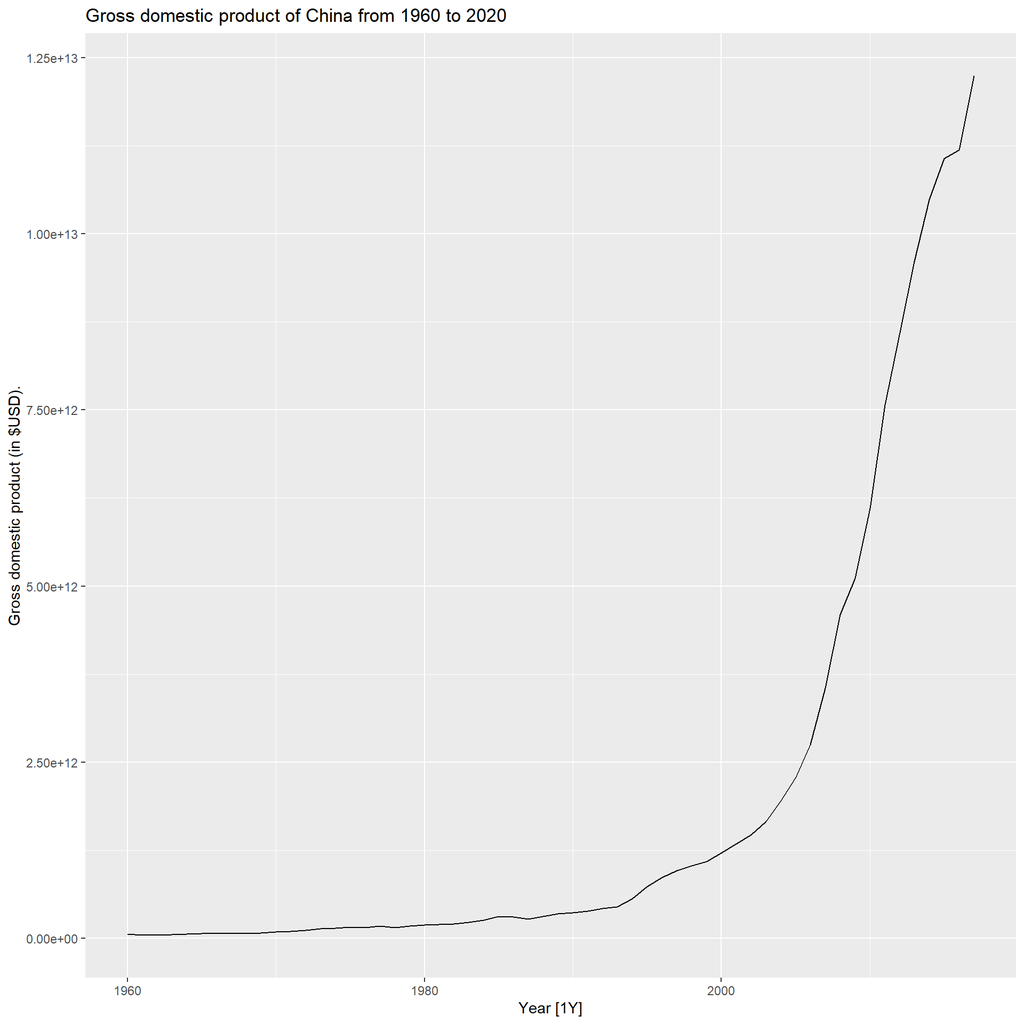

```r
china <- global_economy %>%
               filter(Country == "China")#%>%

china %>%
      autoplot(GDP) +
      labs(y = "Gross domestic product (in $USD).", title = "Gross domestic product of China from 1960 to 2020")
```

China GDP shows an exponential growth from year 2000+. No wonder, China is the factory of the world.

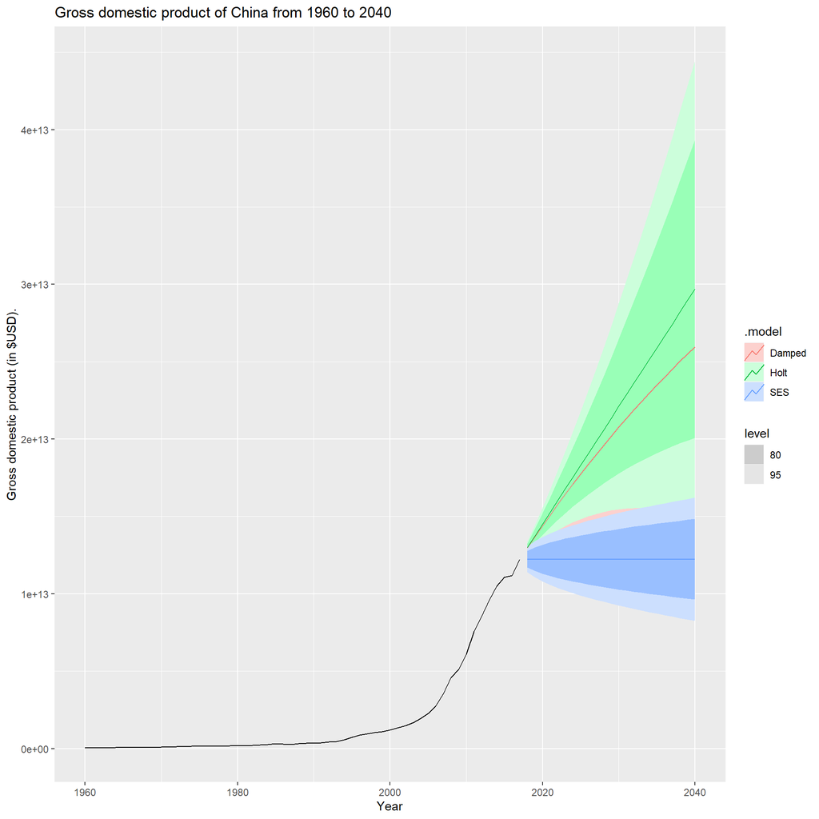

```r
#lambda1 <- BoxCox.lambda(china$GDP)
#Box_cox = ETS (BoxCox(GDP, lambda1) ~ error("A") + trend("A") + season("N")),

fit <- china %>%
  #stretch_tsibble(.init = 10) %>%
  model(
    SES = ETS(GDP ~ error("A") + trend("N") + season("N")),
    Holt = ETS(GDP ~ error("A") + trend("A") + season("N")),
    Damped = ETS(GDP ~ error("A") + trend("Ad") +
                   season("N"))
  ) %>%
  forecast(h = 23) #%>%  accuracy(china)

fit %>%
  autoplot(china)+
      labs(y = "Gross domestic product (in $USD).", title = "Gross domestic product of China from 1960 to 2040")
```

## Exercise 7. Find an ETS model for the Gas data from aus_production and forecast the next few years. Why is multiplicative seasonality necessary here? Experiment with making the trend damped. Does it improve the forecasts?

```r
??aus_production
aus1 <- aus_production
sum(is.na(aus1$Gas))
```

```
## [1] 0
```

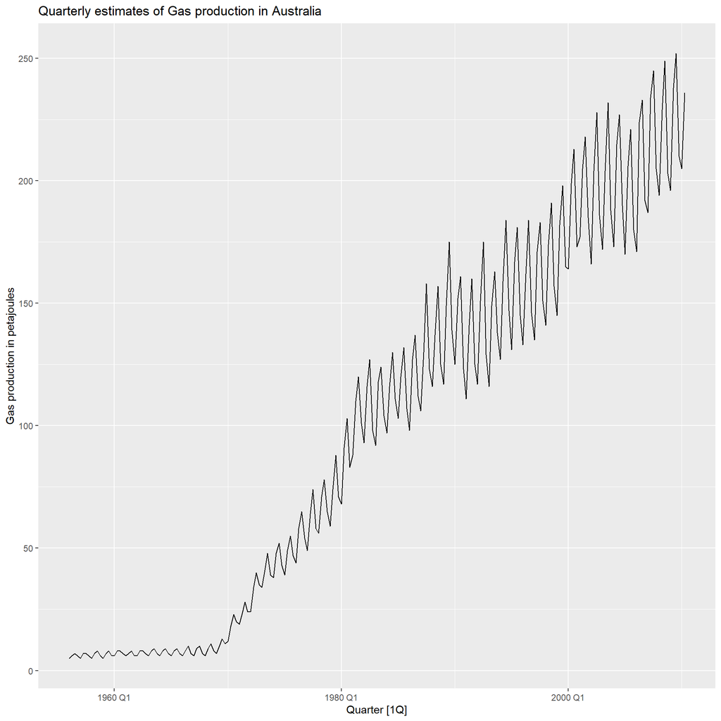

```r
# not good , need a fix...aus1 %>% filter(!is.na(Bricks))
#aus2 <- aus1 %>% na.omit(aus1$Gas)
#mydata = mydata[complete.cases(mydata), ]

#aus1 %>% drop_na(Bricks)

aus1 %>%
  autoplot(Gas)+  labs(y = "Gas production in petajoules", title = "Quarterly estimates of Gas production in Australia")
```

We don’t see a constant peak but rather an exponential trend for Australia Gas production. So,the multiplicative seasonality is more suitable.

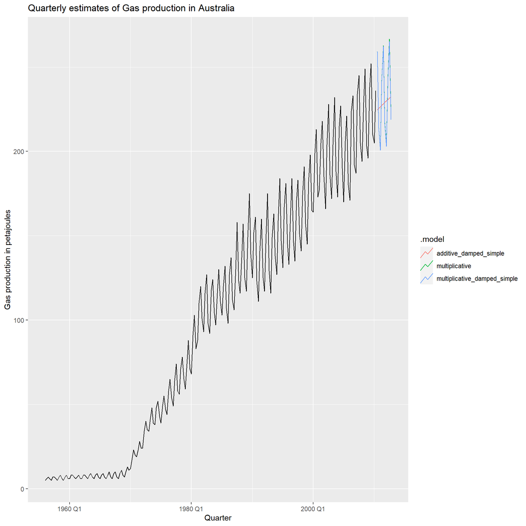

```r
# Short_hand    Method
# (N,N)     Simple exponential smoothing
# (A,N)     Holt’s linear method
# (Ad,N)    Additive damped trend method
# (A,A)     Additive Holt-Winters’ method
# (A,M)     Multiplicative Holt-Winters’ method
# (Ad,M)    Holt-Winters’ damped method


fit <- aus1 %>%
  #stretch_tsibble(.init = 10) %>%
  model(
        #additive = ETS(Gas ~ error("A") + trend("A") +
        #                                        season("A")),
    multiplicative = ETS(Gas ~ error("M") + trend("A") +
                                                season("M")),
    additive_damped_simple = ETS(Gas ~ error("A") + trend("Ad") +
                                                season("N")),
    multiplicative_damped_simple = ETS(Gas ~ error("M") + trend("Ad") +
                                                season("M"))

    #SES = ETS(GDP ~ error("A") + trend("N") + season("N")),
    #Holt = ETS(GDP ~ error("A") + trend("A") + season("N")),
    #Damped = ETS(Gas ~ error("A") + trend("Ad") +                   season("N"))
  ) %>%
  forecast(h = 10) #%>%  accuracy(china)

fit %>%
  autoplot(aus1, level = NULL)+
      labs(y = "Gas production in petajoules", title = "Quarterly estimates of Gas production in Australia")
```

We clearly see that the multiplicative seasonality is suitable for the forecasting of Australia Gas production.

## Exercise 8. Recall your retail time series data (from Exercise 8 in Section 2.10).

a-Why is multiplicative seasonality necessary for this series?

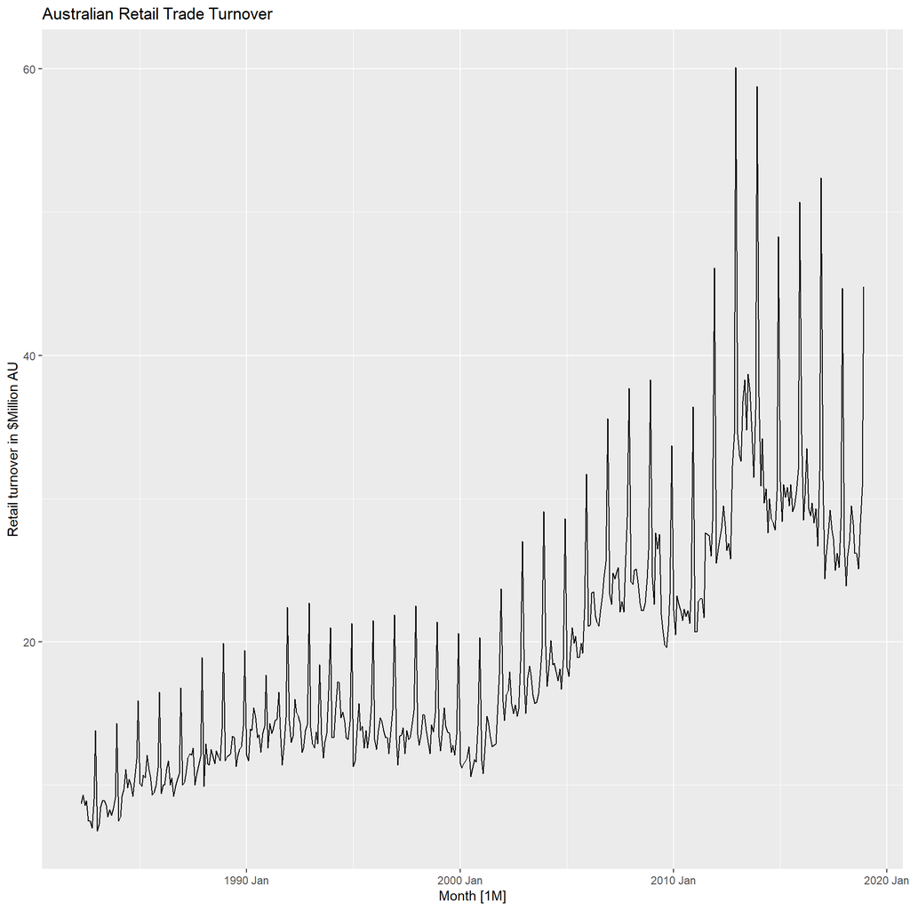

```r
view(aus_retail)
#head(aus_retail)
??aus_retail
set.seed(1278)
myseries <- aus_retail %>%
  filter(`Series ID` == sample(aus_retail$`Series ID`,1))

#aus8 <- aus_retail %>%
#                   filter(Industry == "Takeaway food services")
myseries %>%
     autoplot(Turnover)+
     labs(y = "Retail turnover in $Million AU", title = "   Australian Retail Trade Turnover")
```

We don’t see a constant peak, therefore, the multiplicative seasonality is more suitable.

b-Apply Holt-Winters’ multiplicative method to the data. Experiment with making the trend damped.

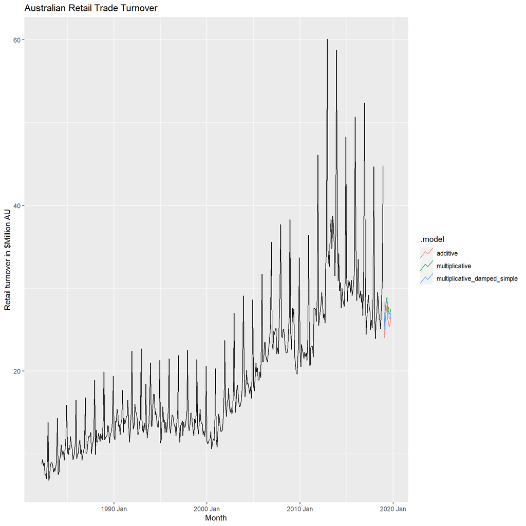

```r
fit <- myseries %>%
  #stretch_tsibble(.init = 10) %>%
  model(
        additive = ETS(Turnover ~ error("A") + trend("A") +
                                                season("A")),
    multiplicative = ETS(Turnover ~ error("M") + trend("A") +
                                                season("M")),
    #additive_damped_simple = ETS(Gas ~ error("A") + trend("Ad") +
     #                                           season("N")),
    multiplicative_damped_simple = ETS(Turnover ~ error("M") + trend("Ad") +
                                                season("M"))

    #SES = ETS(GDP ~ error("A") + trend("N") + season("N")),
    #Holt = ETS(GDP ~ error("A") + trend("A") + season("N")),
    #Damped = ETS(Gas ~ error("A") + trend("Ad") +                   season("N"))
  ) %>%
  forecast(h = 10) #%>%  accuracy(china)

fit %>%
  autoplot(myseries, level = NULL)+
     labs(y = "Retail turnover in $Million AU", title = "   Australian Retail Trade Turnover")
```

c-Compare the RMSE of the one-step forecasts from the two methods. Which do you prefer?

```r
series1 <- myseries %>%
  stretch_tsibble(.init = 10) %>%
  model(
        additive = ETS(Turnover ~ error("A") + trend("A") +
                                                season("A")),
    multiplicative = ETS(Turnover ~ error("M") + trend("A") +
                                                season("M")),
    #additive_damped_simple = ETS(Gas ~ error("A") + trend("Ad") +
     #                                           season("N")),
    multiplicative_damped_simple = ETS(Turnover ~ error("M") + trend("Ad") +
                                                season("M"))

    #SES = ETS(GDP ~ error("A") + trend("N") + season("N")),
    #Holt = ETS(GDP ~ error("A") + trend("A") + season("N")),
    #Damped = ETS(Gas ~ error("A") + trend("Ad") +                   season("N"))
  ) %>%
  forecast(h = 1) %>%
                   accuracy(myseries)
series1
```

```
## # A tibble: 3 x 12
##   .model   State Industry   .type       ME  RMSE   MAE     MPE  MAPE  MASE RMSSE
##   <chr>    <chr> <chr>      <chr>    <dbl> <dbl> <dbl>   <dbl> <dbl> <dbl> <dbl>
## 1 additive Tasm~ Clothing,~ Test  -0.0168   1.74  1.17 -0.664   5.92 0.625 0.630
## 2 multipl~ Tasm~ Clothing,~ Test  -0.00611  1.59  1.11 -0.447   5.78 0.592 0.573
## 3 multipl~ Tasm~ Clothing,~ Test   0.0843   1.59  1.10  0.0922  5.69 0.587 0.573
## # ... with 1 more variable: ACF1 <dbl>
```

d- Check that the residuals from the best method look like white noise.

```r
 myseries %>%
 # stretch_tsibble(.init = 10) %>%
  model(
       # additive = ETS(Turnover ~ error("A") + trend("A") +
        #                                        season("A")),
    #multiplicative = ETS(Turnover ~ error("M") + trend("A") +
    #                                            season("M")),
    #additive_damped_simple = ETS(Gas ~ error("A") + trend("Ad") +
     #                                           season("N")),
    multiplicative_damped_simple = ETS(Turnover ~ error("M") + trend("Ad") +
                                                season("M"))

    #SES = ETS(GDP ~ error("A") + trend("N") + season("N")),
    #Holt = ETS(GDP ~ error("A") + trend("A") + season("N")),
    #Damped = ETS(Gas ~ error("A") + trend("Ad") +                   season("N"))
  ) %>%
  gg_tsresiduals()
```

[figure not shown]